# Labb3 (1)

```python
!jupyter nbconvert --to html "/content/Labb3.ipynb"
```

```
[NbConvertApp] Converting notebook /content/Labb3.ipynb to html
[NbConvertApp] WARNING | Alternative text is missing on 15 image(s).
[NbConvertApp] Writing 2267661 bytes to /content/Labb3.html
```

### Exercise 1

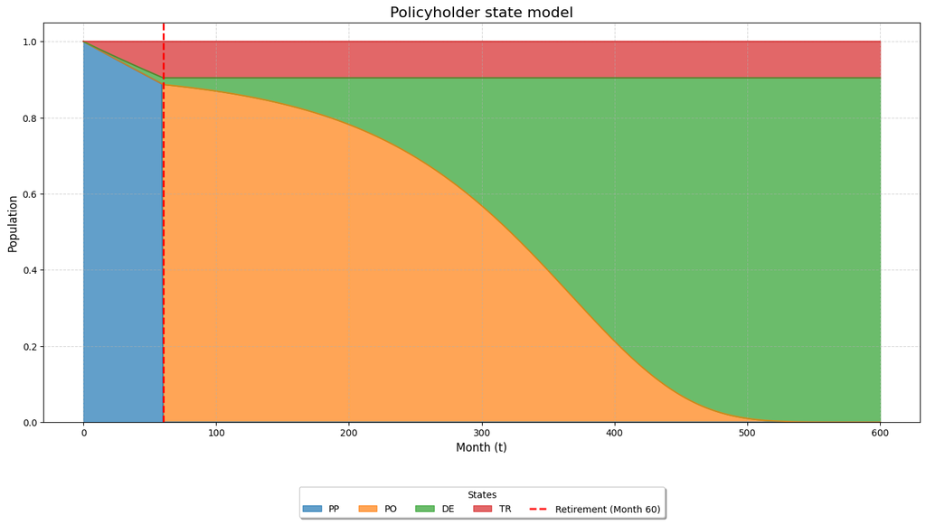

```
Initial Populations (t=0):
PP       1.0
PO       0.0
TR       0.0
DE       0.0
Total    1.0
Name: 0, dtype: float64

Final Populations (t=600):
PP       0.0
PO       0.0
TR       0.1
DE       0.9
Total    1.0
Name: 600, dtype: float64
```

```python
import numpy as np
import pandas as pd
import matplotlib.pyplot as plt


a_women = 0.0007712170
b_women = 0.0000005643
gamma_women = 0.136789

TOTAL_MONTHS = 600
INITIAL_POP_PP = 1
INITIAL_POP_PO = 0
INITIAL_POP_DE = 0
INITIAL_POP_TR = 0

INITIAL_AGE_YEARS = 60
RETIREMENT_AGE_YEARS = 65
YEARLY_TRANSFER_RATE = 0.02

# ----------------------------------------------------------------------------

def get_monthly_mortality_prob(age_years):
    force_of_mortality = a_women + b_women * np.exp(gamma_women * age_years)
    yearly_prob = 1 - np.exp(-force_of_mortality)
    monthly_prob = 1 - (1 - yearly_prob)**(1/12)
    return monthly_prob

def get_monthly_transfer_prob(yearly_prob):
    return 1 - (1 - yearly_prob)**(1/12)

def run_simulation():
    retirement_month_t = int((RETIREMENT_AGE_YEARS - INITIAL_AGE_YEARS) * 12)
    s_m = get_monthly_transfer_prob(YEARLY_TRANSFER_RATE)

    cols = ['PP', 'PO', 'TR', 'DE']
    populations = pd.DataFrame(0.0, index=range(TOTAL_MONTHS + 1), columns=cols)
    populations.loc[0] = [INITIAL_POP_PP, INITIAL_POP_PO, INITIAL_POP_TR, INITIAL_POP_DE]


    for t in range(1, TOTAL_MONTHS + 1):
        pop_pp_last = populations.loc[t-1, 'PP']
        pop_po_last = populations.loc[t-1, 'PO']
        pop_de_last = populations.loc[t-1, 'DE']
        pop_tr_last = populations.loc[t-1, 'TR']
        current_age_years = INITIAL_AGE_YEARS + (t - 1) / 12.0
        q_m = get_monthly_mortality_prob(current_age_years)

        t_pp_de = pop_pp_last * q_m
        t_po_de = pop_po_last * q_m

        t_pp_tr = (pop_pp_last - t_pp_de) * s_m

        t_pp_po = 0.0
        if t == retirement_month_t:
            t_pp_po = pop_pp_last - t_pp_de - t_pp_tr
        pop_pp_new = pop_pp_last - t_pp_de - t_pp_tr - t_pp_po
        pop_po_new = pop_po_last - t_po_de + t_pp_po
        pop_de_new = pop_de_last + t_pp_de + t_po_de
        pop_tr_new = pop_tr_last + t_pp_tr
        populations.loc[t] = [pop_pp_new, pop_po_new, pop_tr_new, pop_de_new]

    populations['Total'] = populations.sum(axis=1)

    return populations

def plot_populations(populations_df):

    plot_df = populations_df[['PP', 'PO', 'DE', 'TR']]

    fig, ax = plt.subplots(figsize=(14, 8))
    plot_df.plot(kind='area', stacked=True, ax=ax, alpha=0.7)

    ax.set_title('Policyholder state model', fontsize=16)
    ax.set_xlabel('Month (t)', fontsize=12)
    ax.set_ylabel('Population', fontsize=12)

    retirement_month_t = int((RETIREMENT_AGE_YEARS - INITIAL_AGE_YEARS) * 12)
    ax.axvline(x=retirement_month_t, color='red', linestyle='--', linewidth=2,label=f'Retirement (Month {retirement_month_t})')
    ax.legend(title='States', loc='upper center', bbox_to_anchor=(0.5, -0.15),
          fancybox=True, shadow=True, ncol=5)
    plt.grid(True, linestyle='--', alpha=0.5)
    plt.tight_layout()

    plt.show()


results = run_simulation()
plot_populations(results)

print("Initial Populations (t=0):")
print(results.loc[0])
print(f"\nFinal Populations (t={TOTAL_MONTHS}):")
print(results.loc[TOTAL_MONTHS].round(2))
```

### Exercise 2

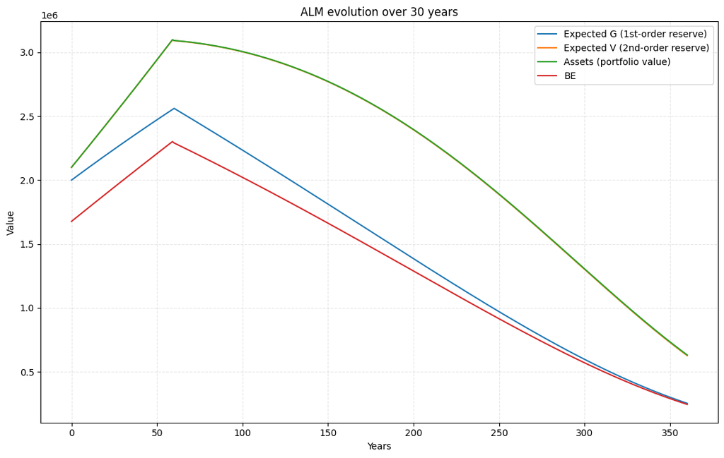

```
 Year   Expected G   Expected V       Assets           BE          BOF
    0 2,000,000.00 2,100,000.00 2,100,000.00 1,677,164.20   422,835.80
    5 2,560,821.14 3,090,303.37 3,091,758.39 2,290,320.86   801,437.53
   10 2,066,663.96 2,926,933.52 2,928,821.97 1,880,451.07 1,048,370.90
   15 1,555,269.25 2,560,322.15 2,562,751.72 1,439,245.85 1,123,505.87
   20 1,051,285.62 1,997,129.79 2,000,237.88   988,700.11 1,011,537.77
   25   597,894.11 1,301,604.15 1,305,566.15   570,739.00   734,827.16
   30   254,011.16   627,192.92   632,232.67   245,669.07   386,563.60
SCR_longevity: 49370.579283016734
```

```python
import numpy as np
import pandas as pd
import matplotlib.pyplot as plt


X = 60
Z = 65
S = 55
U = Z - X

ANNUAL_PREMIUM = 120_000
G0 = 2_000_000
V0 = 2_100_000
PROGNOSIS_RATE = 0.02
TRANSFER_RATE = 0.02
FLAT_DISCOUNT = 0.03

N_ALM = 360
N_POP = 600

alpha_w = 0.0007712170
beta_w  = 0.0000005643
gamma_w = 0.136789

# -------------------- MORTALITY / SURVIVAL --------------------

def survival_func(age_years, a, b, g):
    return np.exp(-a * age_years - (b / g) * (np.exp(g * age_years) - 1))

def S_conditional(x0, t_months, a=alpha_w, b=beta_w, g=gamma_w):
    t_years = t_months / 12
    num = survival_func(x0 + t_years, a, b, g)
    den = survival_func(x0, a, b, g)
    return num / den

def q_monthly(age_years, a=alpha_w, b=beta_w, g=gamma_w):
    l_x      = survival_func(age_years, a, b, g)
    l_x_next = survival_func(age_years + 1/12, a, b, g)
    return 1 - l_x_next / l_x

# -------------------- FIRST-ORDER RESERVE G(t) --------------------

def compute_b_and_G_path(alpha, beta, gamma):
    s_c = np.log(1 + PROGNOSIS_RATE)
    t_pay = np.arange(12*U + 1, 12*(U + S) + 1)
    t_pre = np.arange(1, 12*U + 1)

    EPV_pay_coeff = (S_conditional(X, t_pay, alpha, beta, gamma) * np.exp(-s_c * t_pay/12)).sum() / 12
    EPV_pre_coeff = (S_conditional(X, t_pre, alpha, beta, gamma) * np.exp(-s_c * t_pre/12)).sum() / 12

    b = (G0 + ANNUAL_PREMIUM * EPV_pre_coeff) / EPV_pay_coeff

    def V_at_age(y):
        epsilon = 1e-9
        t_prem_months = max(0, int(np.floor(12 * (Z - y + epsilon))))

        if t_prem_months > 0:
            t = np.arange(1, t_prem_months + 1)
            EPVprem = (S_conditional(y, t, alpha, beta, gamma) * np.exp(-s_c * t/12)).sum() / 12 * ANNUAL_PREMIUM
        else:
            EPVprem = 0

        MAX_AGE = Z + S
        t_max_months = max(0, int(np.floor(12 * (MAX_AGE - y + epsilon))))
        t_first_pay = max(1, int(np.floor(12 * (Z - y + epsilon))) + 1)

        if t_max_months > 0:

            t = np.arange(t_first_pay, t_max_months + 1)
            EPVpay  = (S_conditional(y, t, alpha, beta, gamma) * np.exp(-s_c * t/12)).sum() / 12 * b
        else:
            EPVpay = b

        return EPVpay - EPVprem

    months = np.arange(0, N_POP + 1)
    G_path = np.array([V_at_age(X + (m/12)) for m in months])

    return b, G_path

b, G_full = compute_b_and_G_path(alpha_w, beta_w, gamma_w)
G_ALM = G_full[:N_ALM + 1]

# -------------------- POPULATION PROCESS (PP, PO, TR, DE) --------------------

def get_monthly_transfer_prob(yearly_prob):
    return 1 - (1 - yearly_prob)**(1/12)

def run_population_sim(initial_age, retirement_age, yearly_transfer_rate, total_months,
                       a=alpha_w, b=beta_w, g=gamma_w):
    retire_month = int((retirement_age - initial_age) * 12)
    s_m = get_monthly_transfer_prob(yearly_transfer_rate)

    cols = ['PP','PO','TR','DE','t_pp_de','t_po_de','t_pp_tr','t_pp_po']
    pop = pd.DataFrame(0.0, index=range(total_months+1), columns=cols)
    pop.loc[0, ['PP','PO','TR','DE']] = [1, 0, 0, 0]

    for t in range(1, total_months+1):
        pp_last = pop.loc[t-1, 'PP']
        po_last = pop.loc[t-1, 'PO']
        tr_last = pop.loc[t-1, 'TR']
        de_last = pop.loc[t-1, 'DE']

        age_prev = initial_age + (t-1)/12
        q_m = q_monthly(age_prev, a, b, g)

        t_pp_de = pp_last * q_m
        t_po_de = po_last * q_m
        t_pp_tr = (pp_last - t_pp_de) * s_m

        t_pp_po = 0
        if t == retire_month:
            t_pp_po = pp_last - t_pp_de - t_pp_tr

        pp_new = pp_last - t_pp_de - t_pp_tr - t_pp_po
        po_new = po_last - t_po_de + t_pp_po
        de_new = de_last + t_pp_de + t_po_de
        tr_new = tr_last + t_pp_tr

        pop.loc[t, ['PP','PO','TR','DE','t_pp_de','t_po_de','t_pp_tr','t_pp_po']] = \
            [pp_new, po_new, tr_new, de_new, t_pp_de, t_po_de, t_pp_tr, t_pp_po]

    pop['Total'] = pop[['PP','PO','TR','DE']].sum(axis=1)
    return pop

pop_full = run_population_sim(X, Z, TRANSFER_RATE, N_POP)
pop_ALM = pop_full.iloc[:N_ALM+1].copy()

alive_prob_ALM = pop_ALM['PP'].values + pop_ALM['PO'].values
t_pp_tr_ALM    = pop_ALM['t_pp_tr'].values
PP_ALM         = pop_ALM['PP'].values
PO_ALM         = pop_ALM['PO'].values

EXP_1reserve = alive_prob_ALM * G_ALM


# -------------------- SECOND-ORDER RESERVE + ASSETS (SCENARIO-DEPENDENT) --------------------

one_scenario = pd.read_csv("OneScenario.csv")

stock_cols = one_scenario.select_dtypes(include=[np.number]).columns[:10]
prices = one_scenario[stock_cols].values

n_stocks = prices.shape[1]
weights = np.full(n_stocks, 1.0 / n_stocks)

port_val = prices @ weights
port_ret = np.zeros(len(port_val))
port_ret[1:] = port_val[1:] / port_val[:-1] - 1

def run_V_and_assets():
    V = np.zeros(N_ALM + 1)
    B_path = np.zeros(N_ALM + 1)
    A = np.zeros(N_ALM + 1)

    V[0] = V0
    A[0] = V0

    delta_g = np.log(1 + PROGNOSIS_RATE)

    for t in range(1, N_ALM + 1):
        age_prev = X + (t - 1)/12
        age_now  = X + t/12

        R_port = port_ret[t]

        q_m = q_monthly(age_prev)
        risk_prem = (q_m / (1 - q_m)) * V[t-1]

        V_pre = (V[t-1] + risk_prem) * (1 + R_port)

        if age_now < Z:
            V_t = V_pre + ANNUAL_PREMIUM / 12
            B_t = 0
        else:
            remaining_years = max(0, Z + S - age_now)
            if remaining_years > 0 and V_pre > 0:
                tau = np.arange(1, int(remaining_years * 12) + 1)
                surv = S_conditional(age_now, tau)
                disc = np.exp(-delta_g * tau / 12)
                annuity = np.sum(surv * disc)
                if annuity > 0:
                    B_ann = 12 * V_pre / annuity
                else:
                    B_ann = b
            else:
                B_ann = 0

            B_t = max(b, B_ann) if remaining_years > 0 else 0
            B_t = min(B_t, 12 * V_pre)

            V_t = V_pre - B_t / 12

        V[t] = max(V_t, 0)
        B_path[t] = B_t


        benefit_t  = PO_ALM[t] * (B_t / 12)
        transfer_t = t_pp_tr_ALM[t] * max(G_ALM[t-1], V[t-1])
        prem_t     = ANNUAL_PREMIUM/12.0 * PP_ALM[t] if age_now < Z else 0

        cf2_t = benefit_t + transfer_t - prem_t
        net_cf_to_assets = -cf2_t

        A_before = A[t-1] * (1 + R_port)
        A[t] = A_before + net_cf_to_assets

    return V, B_path, A

V_path, B_path, A_path = run_V_and_assets()

EXP_2reserve = alive_prob_ALM * V_path

# -------------------- BE AND BOF --------------------

def calc_cf1(pop_df, G_full, b_annual, P, n_steps):
    cf1 = np.zeros(n_steps + 1)
    PP = pop_df['PP'].values
    PO = pop_df['PO'].values
    TTR = pop_df['t_pp_tr'].values
    for t in range(1, n_steps + 1):
        cf1[t] = (PO[t] * (b_annual / 12) +
                  TTR[t] * G_full[t-1] -
                  PP[t] * (P / 12))
    return cf1

def calc_BE_series(cf1, flat_rate, horizon_months):

    N = horizon_months
    BE = np.zeros(N_ALM + 1)
    for t in range(N_ALM + 1):
        if t >= N:
            BE[t] = 0
            continue
        future_cf = cf1[t+1:N+1]
        if future_cf.size == 0:
            BE[t] = 0
            continue
        T = np.arange(1, future_cf.size + 1) / 12
        d = np.exp(-flat_rate * T)
        BE[t] = np.sum(future_cf * d)
    return BE

cf1_full = calc_cf1(pop_full, G_full, b, ANNUAL_PREMIUM, N_POP)
BE_t = calc_BE_series(cf1_full, FLAT_DISCOUNT, N_POP)

# BOF(t) = Assets(t) - BE(t)
BE_ALM = BE_t[:N_ALM + 1]
BOF = A_path - BE_ALM

# -------------------- PLOT  --------------------

months = np.arange(0, N_ALM + 1)

plt.figure(figsize=(11, 7))
plt.plot(months, EXP_1reserve, label="Expected G (1st-order reserve)")
plt.plot(months, EXP_2reserve, label="Expected V (2nd-order reserve)")
plt.plot(months, A_path, label="Assets (portfolio value)")
plt.plot(months, BE_ALM, label="BE")
plt.xlabel("Years")
plt.ylabel("Value")
plt.title("ALM evolution over 30 years")
plt.grid(alpha=0.3, linestyle="--")
plt.legend()
plt.tight_layout()
plt.show()

# -------------------- TABLE EVERY 5 YEARS  --------------------

years = np.arange(0, 31, 5)
idx_months = (years * 12).astype(int)

table = pd.DataFrame({"Year": years, "Expected G": EXP_1reserve[idx_months], "Expected V": EXP_2reserve[idx_months], "Assets": A_path[idx_months], "BE": BE_ALM[idx_months], "BOF": BOF[idx_months]})
pd.set_option('display.float_format', '{:,.2f}'.format)
print(table.to_string(index=False))

# ---------- SCR LONGEVITY  ----------
#10% change
a_long = alpha_w * 0.9
b_long = beta_w * 0.9
gamma_long = gamma_w

BOF_0_base = BOF[0]
pop_risk = run_population_sim(X, Z, TRANSFER_RATE, N_POP, a_long, b_long, gamma_long)
cf1_risk = calc_cf1(pop_risk, G_full, b, ANNUAL_PREMIUM, N_POP)
BE_risk = calc_BE_series(cf1_risk, FLAT_DISCOUNT, N_POP)
BOF_0_risk = A_path[0] - BE_risk[0]

SCR_longevity = max(0 , (BOF_0_base - BOF_0_risk))
print("SCR_longevity:", SCR_longevity)
```

### Exercise 3 (a through d)

```python
import numpy as np
import pandas as pd
import matplotlib.pyplot as plt

X = 60
Z = 65
S = 55
U = Z - X
ANNUAL_PREMIUM = 120000
G0 = 2000000
V0 = 2100000
PROGNOSIS_RATE = 0.02
TRANSFER_RATE = 0.02
N_MONTHS = 12
N_POP = 600

alpha_w = 0.0007712170
beta_w = 0.0000005643
gamma_w = 0.136789

def survival_func(age_years, a, b, g):
    return np.exp(-a * age_years - (b / g) * (np.exp(g * age_years) - 1))

def S_conditional(x0, t_months, a=alpha_w, b=beta_w, g=gamma_w):
    t_years = t_months / 12.0
    num = survival_func(x0 + t_years, a, b, g)
    den = survival_func(x0, a, b, g)
    return num / den

def q_monthly(age_years, a=alpha_w, b=beta_w, g=gamma_w):
    l_x = survival_func(age_years, a, b, g)
    l_x_next = survival_func(age_years + 1/12.0, a, b, g)
    return 1.0 - l_x_next / l_x

def compute_b_and_G_path():
    s_c = np.log(1 + PROGNOSIS_RATE)
    t_pay = np.arange(12*U + 1, 12*(U + S) + 1, dtype=int)
    t_pre = np.arange(1, 12*U + 1, dtype=int)
    EPV_pay_coeff = (S_conditional(X, t_pay) * np.exp(-s_c * t_pay/12.0)).sum() / 12.0
    EPV_pre_coeff = (S_conditional(X, t_pre) * np.exp(-s_c * t_pre/12.0)).sum() / 12.0
    b_payout = (G0 + ANNUAL_PREMIUM * EPV_pre_coeff) / EPV_pay_coeff

    def V_at_age(y):
        t_prem = max(0, int(12 * (Z - y)))
        t_first_pay = max(1, int(12 * (Z - y)) + 1)
        if t_prem > 0:
            t = np.arange(1, t_prem + 1, dtype=int)
            EPVprem = (S_conditional(y, t) * np.exp(-s_c * t/12.0)).sum() / 12.0 * ANNUAL_PREMIUM
        else:
            EPVprem = 0.0
        if y < 120:
            t = np.arange(t_first_pay, int(12 * (120 - y)) + 1, dtype=int)
            EPVpay = (S_conditional(y, t) * np.exp(-s_c * t/12.0)).sum() / 12.0 * b_payout
        else:
            EPVpay = 0.0
        return EPVpay - EPVprem

    months = np.arange(0, N_POP + 1)
    G_path = np.array([V_at_age(X + m/12.0) for m in months])
    return b_payout, G_path

def run_population_sim(initial_age, retirement_age, yearly_transfer_rate, total_months,
                       a=alpha_w, b_m=beta_w, g=gamma_w):
    retire_month = int((retirement_age - initial_age) * 12)
    s_m = 1 - (1 - yearly_transfer_rate)**(1/12)
    cols = ['PP','PO','TR','DE','t_pp_de','t_po_de','t_pp_tr','t_pp_po']
    pop = pd.DataFrame(0.0, index=range(total_months+1), columns=cols)
    pop.loc[0, ['PP','PO','TR','DE']] = [1.0, 0.0, 0.0, 0.0]

    for t in range(1, total_months+1):
        pp_last = pop.loc[t-1, 'PP']
        po_last = pop.loc[t-1, 'PO']
        age_prev = initial_age + (t-1)/12.0
        q_m = q_monthly(age_prev, a, b_m, g)
        t_pp_de = pp_last * q_m
        t_po_de = po_last * q_m
        t_pp_tr = (pp_last - t_pp_de) * s_m
        t_pp_po = pp_last - t_pp_de - t_pp_tr if t == retire_month else 0.0
        pp_new = pp_last - t_pp_de - t_pp_tr - t_pp_po
        po_new = po_last - t_po_de + t_pp_po
        de_new = pop.loc[t-1, 'DE'] + t_pp_de + t_po_de
        tr_new = pop.loc[t-1, 'TR'] + t_pp_tr
        pop.loc[t, ['PP','PO','TR','DE','t_pp_de','t_po_de','t_pp_tr','t_pp_po']] = \
            [pp_new, po_new, tr_new, de_new, t_pp_de, t_po_de, t_pp_tr, t_pp_po]
    return pop

def interpolate_rate(T, rates):
    maturities = [5, 10, 15, 20, 30]
    if T <= 5:
        return rates[0]
    elif T >= 30:
        return rates[4]
    for i in range(4):
        if maturities[i] <= T <= maturities[i+1]:
            w = (T - maturities[i]) / (maturities[i+1] - maturities[i])
            return rates[i] + w * (rates[i+1] - rates[i])
    return rates[4]

def calc_BE_at_t(t_now, cf1, rates_at_t, horizon_months):
    if t_now >= horizon_months:
        return 0.0
    BE = 0.0
    for t in range(t_now + 1, horizon_months + 1):
        T = (t - t_now) / 12.0
        r = interpolate_rate(T, rates_at_t)
        BE += cf1[t] * np.exp(-r * T)
    return BE

def calc_cf1_array(pop_df, G_path, b_annual, P, n_steps):
    cf1 = np.zeros(n_steps + 1)
    PP = pop_df['PP'].values
    PO = pop_df['PO'].values
    TTR = pop_df['t_pp_tr'].values
    for t in range(1, n_steps + 1):
        cf1[t] = PO[t] * (b_annual / 12.0) + TTR[t] * G_path[t-1] - PP[t] * (P / 12.0)
    return cf1

def load_scenarios(filepath):
    df = pd.read_csv(filepath)
    scenarios = df['Scenario'].unique()
    n_scenarios = len(scenarios)
    n_periods = len(df[df['Scenario'] == scenarios[0]])

    stock_cols = ['BA', 'CAT', 'KO', 'DIS', 'JPM', 'MMM', 'MSFT', 'PFE', 'WMT', 'XOM']
    bond_cols = ['Z5', 'Z10', 'Z15', 'Z20', 'Z30']
    rate_cols = ['Y5', 'Y10', 'Y15', 'Y20', 'Y30']

    stocks = np.zeros((n_scenarios, n_periods, 10))
    bonds = np.zeros((n_scenarios, n_periods, 5))
    rates = np.zeros((n_scenarios, n_periods, 5))

    for i, scen in enumerate(scenarios):
        scen_data = df[df['Scenario'] == scen].sort_values('Period')
        stocks[i] = scen_data[stock_cols].values
        bonds[i] = scen_data[bond_cols].values
        rates[i] = scen_data[rate_cols].values

    return stocks, bonds, rates, n_scenarios, n_periods

def run_alm_bh_bonds_only(stocks, bonds, rates, bond_idx, n_months,
                          b_annual, G_path, PP_arr, PO_arr, t_pp_tr_arr, cf1_full):
    n_scenarios = stocks.shape[0]
    BOF_final = np.zeros(n_scenarios)
    delta_g = np.log(1 + PROGNOSIS_RATE)

    for scen in range(n_scenarios):
        A = np.zeros(n_months + 1)
        V = np.zeros(n_months + 1)
        A[0] = V0
        V[0] = V0

        bond_units = V0 / bonds[scen, 0, bond_idx]

        for t in range(1, n_months + 1):
            age_prev = X + (t - 1)/12.0
            age_now = X + t/12.0

            bond_val_prev = bond_units * bonds[scen, t-1, bond_idx]
            bond_val_now = bond_units * bonds[scen, t, bond_idx]
            R_port = (bond_val_now / bond_val_prev) - 1.0 if bond_val_prev > 0 else 0.0

            q_m = q_monthly(age_prev)
            risk_prem = (q_m / (1.0 - q_m)) * V[t-1]
            V_pre = (V[t-1] + risk_prem) * (1.0 + R_port)

            if age_prev < Z:
                V_t = V_pre + ANNUAL_PREMIUM / 12.0
                B_t = 0.0
            else:
                remaining_years = max(0.0, Z + S - age_now)
                if remaining_years > 0 and V_pre > 0:
                    tau = np.arange(1, int(remaining_years * 12) + 1)
                    annuity = np.sum(S_conditional(age_now, tau) * np.exp(-delta_g * tau / 12.0))
                    B_ann = 12.0 * V_pre / annuity if annuity > 0 else b_annual
                else:
                    B_ann = 0.0
                B_t = min(max(b_annual, B_ann) if remaining_years > 0 else 0.0, 12.0 * V_pre)
                V_t = V_pre - B_t / 12.0
```

```python
            V[t] = max(V_t, 0.0)

            benefit_t = PO_arr[t] * (B_t / 12.0)
            transfer_t = t_pp_tr_arr[t] * max(G_path[t-1], V[t-1])
            prem_t = ANNUAL_PREMIUM/12.0 * PP_arr[t] if age_prev < Z else 0.0
            cf2_t = benefit_t + transfer_t - prem_t

            A[t] = bond_val_now - cf2_t

            if bonds[scen, t, bond_idx] > 0:
                bond_units = A[t] / bonds[scen, t, bond_idx]
            else:
                bond_units = 0

        BE_final = calc_BE_at_t(n_months, cf1_full, rates[scen, n_months, :], N_POP)
        BOF_final[scen] = A[n_months] - BE_final

    return BOF_final

def run_alm_bh_mixed(stocks, bonds, rates, stock_frac, bond_idx, n_months,
                     b_annual, G_path, PP_arr, PO_arr, t_pp_tr_arr, cf1_full):
    n_scenarios = stocks.shape[0]
    BOF_final = np.zeros(n_scenarios)
    delta_g = np.log(1 + PROGNOSIS_RATE)

    for scen in range(n_scenarios):
        A = np.zeros(n_months + 1)
        V = np.zeros(n_months + 1)
        A[0] = V0
        V[0] = V0

        stock_alloc = V0 * stock_frac
        bond_alloc = V0 * (1 - stock_frac)

        stock_units = np.array([(stock_alloc / 10) / stocks[scen, 0, i] for i in range(10)])
        bond_units = bond_alloc / bonds[scen, 0, bond_idx]

        for t in range(1, n_months + 1):
            age_prev = X + (t - 1)/12.0
            age_now = X + t/12.0

            stock_val_prev = sum(stock_units[i] * stocks[scen, t-1, i] for i in range(10))
            stock_val_now = sum(stock_units[i] * stocks[scen, t, i] for i in range(10))
            bond_val_prev = bond_units * bonds[scen, t-1, bond_idx]
            bond_val_now = bond_units * bonds[scen, t, bond_idx]

            total_prev = stock_val_prev + bond_val_prev
            total_now = stock_val_now + bond_val_now
            R_port = (total_now / total_prev) - 1.0 if total_prev > 0 else 0.0

            q_m = q_monthly(age_prev)
            risk_prem = (q_m / (1.0 - q_m)) * V[t-1]
            V_pre = (V[t-1] + risk_prem) * (1.0 + R_port)

            if age_prev < Z:
                V_t = V_pre + ANNUAL_PREMIUM / 12.0
                B_t = 0.0
            else:
                remaining_years = max(0.0, Z + S - age_now)
                if remaining_years > 0 and V_pre > 0:
                    tau = np.arange(1, int(remaining_years * 12) + 1)
                    annuity = np.sum(S_conditional(age_now, tau) * np.exp(-delta_g * tau / 12.0))
                    B_ann = 12.0 * V_pre / annuity if annuity > 0 else b_annual
                else:
                    B_ann = 0.0
                B_t = min(max(b_annual, B_ann) if remaining_years > 0 else 0.0, 12.0 * V_pre)
                V_t = V_pre - B_t / 12.0

            V[t] = max(V_t, 0.0)

            benefit_t = PO_arr[t] * (B_t / 12.0)
            transfer_t = t_pp_tr_arr[t] * max(G_path[t-1], V[t-1])
            prem_t = ANNUAL_PREMIUM/12.0 * PP_arr[t] if age_prev < Z else 0.0
            cf2_t = benefit_t + transfer_t - prem_t

            A[t] = total_now - cf2_t

            if A[t] > 0 and total_now > 0:
                ratio = A[t] / total_now
                stock_units = stock_units * ratio
                bond_units = bond_units * ratio
            else:
                stock_units = np.zeros(10)
                bond_units = 0

        BE_final = calc_BE_at_t(n_months, cf1_full, rates[scen, n_months, :], N_POP)
        BOF_final[scen] = A[n_months] - BE_final

    return BOF_final

def calculate_scr(BOF_final, BOF_0):
    return np.percentile(BOF_0 - BOF_final, 95)

def calc_cf1_duration(t_now, cf1, rates_at_t, horizon_months):
    if t_now >= horizon_months:
        return 5.0
    pv_total = 0.0
    duration_sum = 0.0
    for t in range(t_now + 1, horizon_months + 1):
        T = (t - t_now) / 12.0
        r = interpolate_rate(T, rates_at_t)
        pv = cf1[t] * np.exp(-r * T)
        pv_total += pv
        duration_sum += T * pv
    if pv_total <= 0:
        return 5.0
    return duration_sum / pv_total

def run_alm_cm_mixed(stocks, bonds, rates, stock_frac, bond_idx, n_months,
                     b_annual, G_path, PP_arr, PO_arr, t_pp_tr_arr, cf1_full):
    n_scenarios = stocks.shape[0]
    BOF_final = np.zeros(n_scenarios)
    delta_g = np.log(1 + PROGNOSIS_RATE)

    for scen in range(n_scenarios):
        A = np.zeros(n_months + 1)
        V = np.zeros(n_months + 1)
        A[0] = V0
        V[0] = V0

        stock_alloc = V0 * stock_frac
        bond_alloc = V0 * (1 - stock_frac)

        stock_units = np.array([(stock_alloc / 10) / stocks[scen, 0, i] for i in range(10)])
        bond_units = bond_alloc / bonds[scen, 0, bond_idx]

        for t in range(1, n_months + 1):
            age_prev = X + (t - 1)/12.0
            age_now = X + t/12.0

            stock_val_prev = sum(stock_units[i] * stocks[scen, t-1, i] for i in range(10))
            stock_val_now = sum(stock_units[i] * stocks[scen, t, i] for i in range(10))
            bond_val_prev = bond_units * bonds[scen, t-1, bond_idx]
            bond_val_now = bond_units * bonds[scen, t, bond_idx]

            total_prev = stock_val_prev + bond_val_prev
            total_now = stock_val_now + bond_val_now
            R_port = (total_now / total_prev) - 1.0 if total_prev > 0 else 0.0

            q_m = q_monthly(age_prev)
            risk_prem = (q_m / (1.0 - q_m)) * V[t-1]
            V_pre = (V[t-1] + risk_prem) * (1.0 + R_port)

            if age_prev < Z:
                V_t = V_pre + ANNUAL_PREMIUM / 12.0
                B_t = 0.0
            else:
                remaining_years = max(0.0, Z + S - age_now)
                if remaining_years > 0 and V_pre > 0:
                    tau = np.arange(1, int(remaining_years * 12) + 1)
                    annuity = np.sum(S_conditional(age_now, tau) * np.exp(-delta_g * tau / 12.0))
                    B_ann = 12.0 * V_pre / annuity if annuity > 0 else b_annual
                else:
                    B_ann = 0.0
                B_t = min(max(b_annual, B_ann) if remaining_years > 0 else 0.0, 12.0 * V_pre)
                V_t = V_pre - B_t / 12.0
```

```python
            V[t] = max(V_t, 0.0)

            benefit_t = PO_arr[t] * (B_t / 12.0)
            transfer_t = t_pp_tr_arr[t] * max(G_path[t-1], V[t-1])
            prem_t = ANNUAL_PREMIUM/12.0 * PP_arr[t] if age_prev < Z else 0.0
            cf2_t = benefit_t + transfer_t - prem_t

            A[t] = total_now - cf2_t

            if A[t] > 0:
                stock_target = A[t] * stock_frac
                bond_target = A[t] * (1 - stock_frac)
                stock_units = np.array([stock_target/10 / stocks[scen, t, i] if stocks[scen, t, i] > 0 else 0 for i in range(10)])
                bond_units = bond_target / bonds[scen, t, bond_idx] if bonds[scen, t, bond_idx] > 0 else 0
            else:
                stock_units = np.zeros(10)
                bond_units = 0

        BE_final = calc_BE_at_t(n_months, cf1_full, rates[scen, n_months, :], N_POP)
        BOF_final[scen] = A[n_months] - BE_final

    return BOF_final

def run_alm_cm_duration(stocks, bonds, rates, stock_frac, n_months,
                        b_annual, G_path, PP_arr, PO_arr, t_pp_tr_arr, cf1_full):
    n_scenarios = stocks.shape[0]
    BOF_final = np.zeros(n_scenarios)
    delta_g = np.log(1 + PROGNOSIS_RATE)

    for scen in range(n_scenarios):
        A = np.zeros(n_months + 1)
        V = np.zeros(n_months + 1)
        A[0] = V0
        V[0] = V0

        D_target = calc_cf1_duration(0, cf1_full, rates[scen, 0, :], N_POP)
        if D_target <= 5:
            w5 = 1.0
        elif D_target >= 30:
            w5 = 0.0
        else:
            w5 = (30 - D_target) / (30 - 5)
        w30 = 1 - w5

        stock_alloc = V0 * stock_frac
        bond_alloc = V0 * (1 - stock_frac)

        stock_units = np.array([(stock_alloc / 10) / stocks[scen, 0, i] for i in range(10)])
        bond_units_5 = (bond_alloc * w5) / bonds[scen, 0, 0]
        bond_units_30 = (bond_alloc * w30) / bonds[scen, 0, 4]

        for t in range(1, n_months + 1):
            age_prev = X + (t - 1)/12.0
            age_now = X + t/12.0

            stock_val_prev = sum(stock_units[i] * stocks[scen, t-1, i] for i in range(10))
            stock_val_now = sum(stock_units[i] * stocks[scen, t, i] for i in range(10))
            bond_val_prev = bond_units_5 * bonds[scen, t-1, 0] + bond_units_30 * bonds[scen, t-1, 4]
            bond_val_now = bond_units_5 * bonds[scen, t, 0] + bond_units_30 * bonds[scen, t, 4]

            total_prev = stock_val_prev + bond_val_prev
            total_now = stock_val_now + bond_val_now
            R_port = (total_now / total_prev) - 1.0 if total_prev > 0 else 0.0

            q_m = q_monthly(age_prev)
            risk_prem = (q_m / (1.0 - q_m)) * V[t-1]
            V_pre = (V[t-1] + risk_prem) * (1.0 + R_port)

            if age_prev < Z:
                V_t = V_pre + ANNUAL_PREMIUM / 12.0
                B_t = 0.0
            else:
                remaining_years = max(0.0, Z + S - age_now)
                if remaining_years > 0 and V_pre > 0:
                    tau = np.arange(1, int(remaining_years * 12) + 1)
                    annuity = np.sum(S_conditional(age_now, tau) * np.exp(-delta_g * tau / 12.0))
                    B_ann = 12.0 * V_pre / annuity if annuity > 0 else b_annual
                else:
                    B_ann = 0.0
                B_t = min(max(b_annual, B_ann) if remaining_years > 0 else 0.0, 12.0 * V_pre)
                V_t = V_pre - B_t / 12.0

            V[t] = max(V_t, 0.0)

            benefit_t = PO_arr[t] * (B_t / 12.0)
            transfer_t = t_pp_tr_arr[t] * max(G_path[t-1], V[t-1])
            prem_t = ANNUAL_PREMIUM/12.0 * PP_arr[t] if age_prev < Z else 0.0
            cf2_t = benefit_t + transfer_t - prem_t

            A[t] = total_now - cf2_t

            if A[t] > 0:
                D_target = calc_cf1_duration(t, cf1_full, rates[scen, t, :], N_POP)
                if D_target <= 5:
                    w5 = 1.0
                elif D_target >= 30:
                    w5 = 0.0
                else:
                    w5 = (30 - D_target) / (30 - 5)
                w30 = 1 - w5

                stock_target = A[t] * stock_frac
                bond_target = A[t] * (1 - stock_frac)
                stock_units = np.array([stock_target/10 / stocks[scen, t, i] if stocks[scen, t, i] > 0 else 0 for i in range(10)])
                bond_units_5 = (bond_target * w5) / bonds[scen, t, 0] if bonds[scen, t, 0] > 0 else 0
                bond_units_30 = (bond_target * w30) / bonds[scen, t, 4] if bonds[scen, t, 4] > 0 else 0
            else:
                stock_units = np.zeros(10)
                bond_units_5 = 0
                bond_units_30 = 0

        BE_final = calc_BE_at_t(n_months, cf1_full, rates[scen, n_months, :], N_POP)
        BOF_final[scen] = A[n_months] - BE_final

    return BOF_final

if __name__ == "__main__":
    b, G_full = compute_b_and_G_path()
    print(f"Annual benefit (b): {b:,.2f}")

    pop_full = run_population_sim(X, Z, TRANSFER_RATE, N_POP)

    cf1_full = calc_cf1_array(pop_full, G_full, b, ANNUAL_PREMIUM, N_POP)

    pop_ALM = pop_full.iloc[:N_MONTHS+1].copy()
    PP_ALM = pop_ALM['PP'].values
    PO_ALM = pop_ALM['PO'].values
    t_pp_tr_ALM = pop_ALM['t_pp_tr'].values
    G_ALM = G_full[:N_MONTHS+1]

    stocks, bonds, rates, n_scenarios, n_periods = load_scenarios("ScenarioFile.csv")

    BE_0 = calc_BE_at_t(0, cf1_full, rates[0, 0, :], N_POP)
    BOF_0 = V0 - BE_0
    print(f"Initial BE: {BE_0:,.2f}")
    print(f"Initial BOF: {BOF_0:,.2f}")

    BOF_3a = run_alm_bh_bonds_only(
        stocks, bonds, rates,
        bond_idx=2,
        n_months=N_MONTHS,
        b_annual=b,
        G_path=G_ALM,
        PP_arr=PP_ALM,
        PO_arr=PO_ALM,
        t_pp_tr_arr=t_pp_tr_ALM,
        cf1_full=cf1_full
    )
    SCR_3a = calculate_scr(BOF_3a, BOF_0)

    BOF_3b = run_alm_bh_mixed(
        stocks, bonds, rates,
        stock_frac=0.5,
        bond_idx=0,
        n_months=N_MONTHS,
        b_annual=b,
        G_path=G_ALM,
        PP_arr=PP_ALM,
        PO_arr=PO_ALM,
        t_pp_tr_arr=t_pp_tr_ALM,
        cf1_full=cf1_full
    )
    SCR_3b = calculate_scr(BOF_3b, BOF_0)
```

```
Annual benefit (b): 165,729.95
Initial BE: 1,217,691.31
Initial BOF: 882,308.69
```

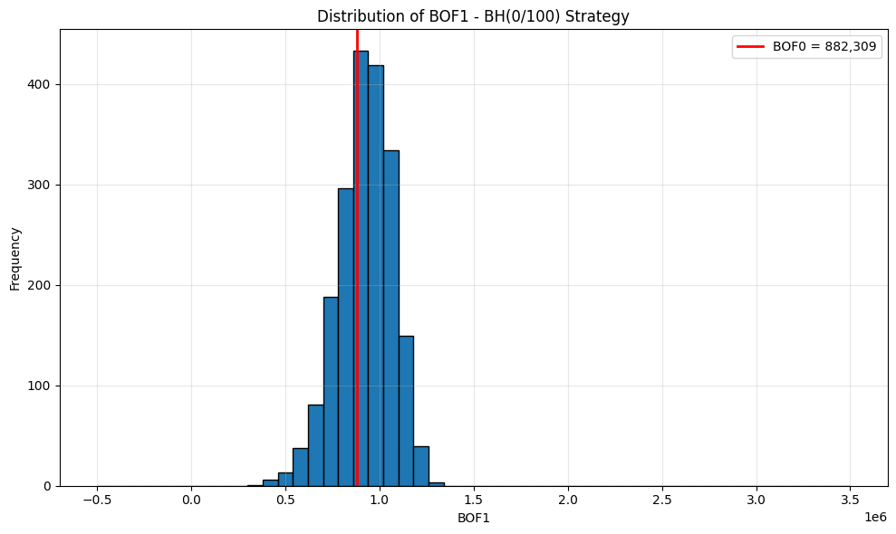

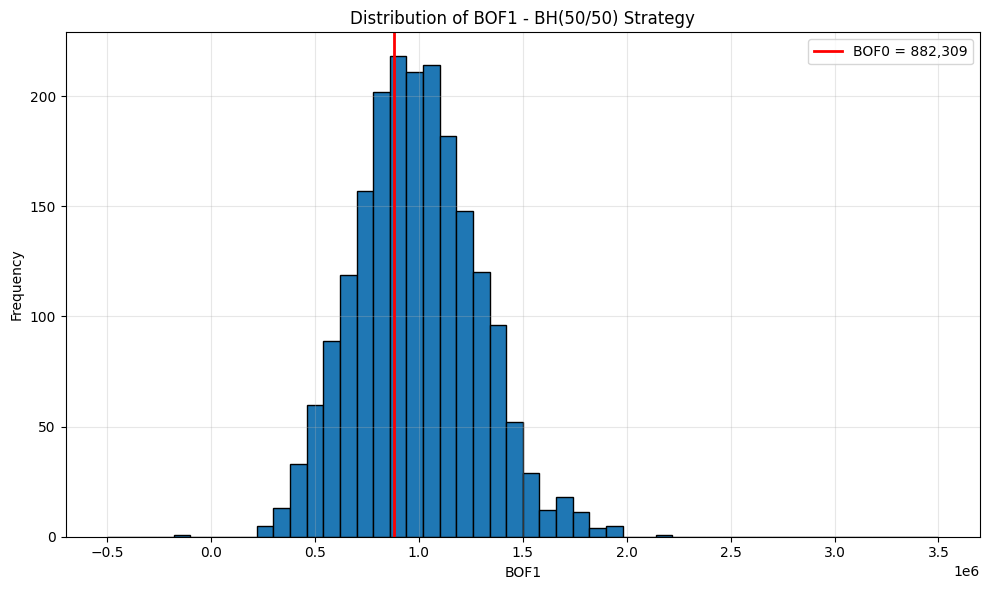

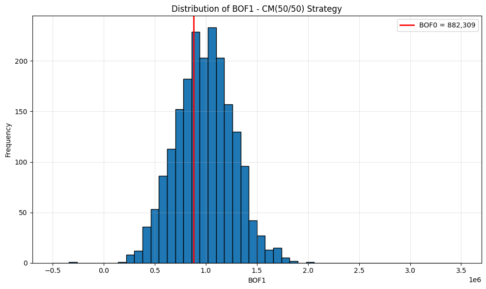

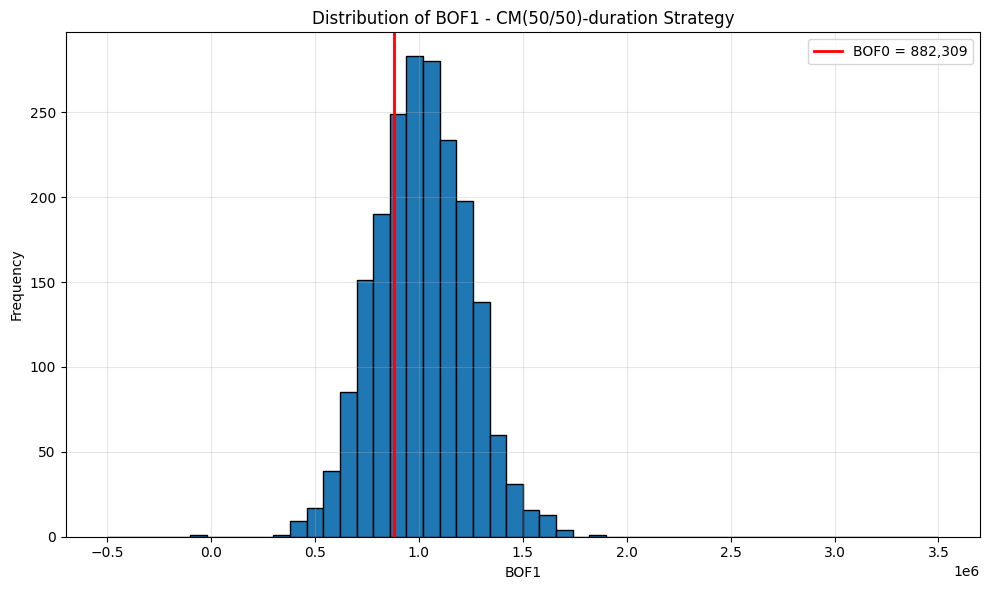

```
Task 3 Results
          Strategy           SCR         BOF_0   Mean BOF_1     Std BOF_1
         BH(0/100) 209060.592178 882308.690472 9.216890e+05 144013.853799
         BH(50/50) 358003.320851 882308.690472 9.883702e+05 289653.603635
         CM(50/50) 360123.547741 882308.690472 9.867701e+05 279125.391780
CM(50/50)-duration 226220.882700 882308.690472 1.013347e+06 221701.435760
```

```python
    BOF_3c = run_alm_cm_mixed(
        stocks, bonds, rates,
        stock_frac=0.5,
        bond_idx=0,
        n_months=N_MONTHS,
        b_annual=b,
        G_path=G_ALM,
        PP_arr=PP_ALM,
        PO_arr=PO_ALM,
        t_pp_tr_arr=t_pp_tr_ALM,
        cf1_full=cf1_full
    )
    SCR_3c = calculate_scr(BOF_3c, BOF_0)

    BOF_3d = run_alm_cm_duration(
        stocks, bonds, rates,
        stock_frac=0.5,
        n_months=N_MONTHS,
        b_annual=b,
        G_path=G_ALM,
        PP_arr=PP_ALM,
        PO_arr=PO_ALM,
        t_pp_tr_arr=t_pp_tr_ALM,
        cf1_full=cf1_full
    )
    SCR_3d = calculate_scr(BOF_3d, BOF_0)

    plt.figure(figsize=(10, 6))
    plt.hist(BOF_3a, bins=50, range=(-500000, 3500000), edgecolor='black')
    plt.title("Distribution of BOF1 - BH(0/100) Strategy")
    plt.xlabel("BOF1")
    plt.ylabel("Frequency")
    plt.grid(True, alpha=0.3)
    plt.axvline(BOF_0, color='red', linewidth=2, label=f'BOF0 = {BOF_0:,.0f}')
    plt.legend()
    plt.tight_layout()
    plt.show()

    plt.figure(figsize=(10, 6))
    plt.hist(BOF_3b, bins=50, range=(-500000, 3500000), edgecolor='black')
    plt.title("Distribution of BOF1 - BH(50/50) Strategy")
    plt.xlabel("BOF1")
    plt.ylabel("Frequency")
    plt.grid(True, alpha=0.3)
    plt.axvline(BOF_0, color='red', linewidth=2, label=f'BOF0 = {BOF_0:,.0f}')
    plt.legend()
    plt.tight_layout()
    plt.show()

    plt.figure(figsize=(10, 6))
    plt.hist(BOF_3c, bins=50, range=(-500000, 3500000), edgecolor='black')
    plt.title("Distribution of BOF1 - CM(50/50) Strategy")
    plt.xlabel("BOF1")
    plt.ylabel("Frequency")
    plt.grid(True, alpha=0.3)
    plt.axvline(BOF_0, color='red', linewidth=2, label=f'BOF0 = {BOF_0:,.0f}')
    plt.legend()
    plt.tight_layout()
    plt.show()

    plt.figure(figsize=(10, 6))
    plt.hist(BOF_3d, bins=50, range=(-500000, 3500000), edgecolor='black')
    plt.title("Distribution of BOF1 - CM(50/50)-duration Strategy")
    plt.xlabel("BOF1")
    plt.ylabel("Frequency")
    plt.grid(True, alpha=0.3)
    plt.axvline(BOF_0, color='red', linewidth=2, label=f'BOF0 = {BOF_0:,.0f}')
    plt.legend()
    plt.tight_layout()
    plt.show()

    results = pd.DataFrame({
        "Strategy": ["BH(0/100)", "BH(50/50)", "CM(50/50)", "CM(50/50)-duration"],
        "SCR": [SCR_3a, SCR_3b, SCR_3c, SCR_3d],
        "BOF_0": [BOF_0, BOF_0, BOF_0, BOF_0],
        "Mean BOF_1": [np.mean(BOF_3a), np.mean(BOF_3b), np.mean(BOF_3c), np.mean(BOF_3d)],
        "Std BOF_1": [np.std(BOF_3a), np.std(BOF_3b), np.std(BOF_3c), np.std(BOF_3d)]
    })

    print("\nTask 3 Results")
    print(results.to_string(index=False))
```

### Exercise 4 (a through d)

```python
import numpy as np
import pandas as pd
import matplotlib.pyplot as plt

X = 60
Z = 65
S = 55
U = Z - X
ANNUAL_PREMIUM = 120000
G0 = 2000000
V0 = 2100000
PROGNOSIS_RATE = 0.02
TRANSFER_RATE = 0.02
N_MONTHS = 120
N_POP = 600

alpha_w = 0.0007712170
beta_w = 0.0000005643
gamma_w = 0.136789

def survival_func(age_years, a, b, g):
    return np.exp(-a * age_years - (b / g) * (np.exp(g * age_years) - 1))

def S_conditional(x0, t_months, a=alpha_w, b=beta_w, g=gamma_w):
    t_years = t_months / 12.0
    num = survival_func(x0 + t_years, a, b, g)
    den = survival_func(x0, a, b, g)
    return num / den

def q_monthly(age_years, a=alpha_w, b=beta_w, g=gamma_w):
    l_x = survival_func(age_years, a, b, g)
    l_x_next = survival_func(age_years + 1/12.0, a, b, g)
    return 1.0 - l_x_next / l_x

def compute_b_and_G_path():
    s_c = np.log(1 + PROGNOSIS_RATE)
    t_pay = np.arange(12*U + 1, 12*(U + S) + 1, dtype=int)
    t_pre = np.arange(1, 12*U + 1, dtype=int)
    EPV_pay_coeff = (S_conditional(X, t_pay) * np.exp(-s_c * t_pay/12.0)).sum() / 12.0
    EPV_pre_coeff = (S_conditional(X, t_pre) * np.exp(-s_c * t_pre/12.0)).sum() / 12.0
    b_payout = (G0 + ANNUAL_PREMIUM * EPV_pre_coeff) / EPV_pay_coeff

    def V_at_age(y):
        t_prem = max(0, int(12 * (Z - y)))
        t_first_pay = max(1, int(12 * (Z - y)) + 1)
        if t_prem > 0:
            t = np.arange(1, t_prem + 1, dtype=int)
            EPVprem = (S_conditional(y, t) * np.exp(-s_c * t/12.0)).sum() / 12.0 * ANNUAL_PREMIUM
        else:
            EPVprem = 0.0
        if y < 120:
            t = np.arange(t_first_pay, int(12 * (120 - y)) + 1, dtype=int)
            EPVpay = (S_conditional(y, t) * np.exp(-s_c * t/12.0)).sum() / 12.0 * b_payout
        else:
            EPVpay = 0.0
        return EPVpay - EPVprem

    months = np.arange(0, N_POP + 1)
    G_path = np.array([V_at_age(X + m/12.0) for m in months])
    return b_payout, G_path

def run_population_sim(initial_age, retirement_age, yearly_transfer_rate, total_months,
                       a=alpha_w, b_m=beta_w, g=gamma_w):
    retire_month = int((retirement_age - initial_age) * 12)
    s_m = 1 - (1 - yearly_transfer_rate)**(1/12)
    cols = ['PP','PO','TR','DE','t_pp_de','t_po_de','t_pp_tr','t_pp_po']
    pop = pd.DataFrame(0.0, index=range(total_months+1), columns=cols)
    pop.loc[0, ['PP','PO','TR','DE']] = [1.0, 0.0, 0.0, 0.0]

    for t in range(1, total_months+1):
        pp_last = pop.loc[t-1, 'PP']
        po_last = pop.loc[t-1, 'PO']
        age_prev = initial_age + (t-1)/12.0
        q_m = q_monthly(age_prev, a, b_m, g)
        t_pp_de = pp_last * q_m
        t_po_de = po_last * q_m
        t_pp_tr = (pp_last - t_pp_de) * s_m
        t_pp_po = pp_last - t_pp_de - t_pp_tr if t == retire_month else 0.0
        pp_new = pp_last - t_pp_de - t_pp_tr - t_pp_po
        po_new = po_last - t_po_de + t_pp_po
        de_new = pop.loc[t-1, 'DE'] + t_pp_de + t_po_de
        tr_new = pop.loc[t-1, 'TR'] + t_pp_tr
        pop.loc[t, ['PP','PO','TR','DE','t_pp_de','t_po_de','t_pp_tr','t_pp_po']] = \
            [pp_new, po_new, tr_new, de_new, t_pp_de, t_po_de, t_pp_tr, t_pp_po]
    return pop

def interpolate_rate(T, rates):
    maturities = [5, 10, 15, 20, 30]
    if T <= 5:
        return rates[0]
    elif T >= 30:
        return rates[4]
    for i in range(4):
        if maturities[i] <= T <= maturities[i+1]:
            w = (T - maturities[i]) / (maturities[i+1] - maturities[i])
            return rates[i] + w * (rates[i+1] - rates[i])
    return rates[4]

def calc_BE_at_t(t_now, cf1, rates_at_t, horizon_months):
    if t_now >= horizon_months:
        return 0.0
    BE = 0.0
    for t in range(t_now + 1, horizon_months + 1):
        T = (t - t_now) / 12.0
        r = interpolate_rate(T, rates_at_t)
        BE += cf1[t] * np.exp(-r * T)
    return BE

def calc_cf1_array(pop_df, G_path, b_annual, P, n_steps):
    cf1 = np.zeros(n_steps + 1)
    PP = pop_df['PP'].values
    PO = pop_df['PO'].values
    TTR = pop_df['t_pp_tr'].values
    for t in range(1, n_steps + 1):
        cf1[t] = PO[t] * (b_annual / 12.0) + TTR[t] * G_path[t-1] - PP[t] * (P / 12.0)
    return cf1

def calc_cf1_duration(t_now, cf1, rates_at_t, horizon_months):
    if t_now >= horizon_months:
        return 5.0
    pv_total = 0.0
    duration_sum = 0.0
    for t in range(t_now + 1, horizon_months + 1):
        T = (t - t_now) / 12.0
        r = interpolate_rate(T, rates_at_t)
        pv = cf1[t] * np.exp(-r * T)
        pv_total += pv
        duration_sum += T * pv
    if pv_total <= 0:
        return 5.0
    return duration_sum / pv_total

def load_scenarios(filepath):
    df = pd.read_csv(filepath)
    scenarios = df['Scenario'].unique()
    n_scenarios = len(scenarios)
    n_periods = len(df[df['Scenario'] == scenarios[0]])

    stock_cols = ['BA', 'CAT', 'KO', 'DIS', 'JPM', 'MMM', 'MSFT', 'PFE', 'WMT', 'XOM']
    bond_cols = ['Z5', 'Z10', 'Z15', 'Z20', 'Z30']
    rate_cols = ['Y5', 'Y10', 'Y15', 'Y20', 'Y30']

    stocks = np.zeros((n_scenarios, n_periods, 10))
    bonds = np.zeros((n_scenarios, n_periods, 5))
    rates = np.zeros((n_scenarios, n_periods, 5))

    for i, scen in enumerate(scenarios):
        scen_data = df[df['Scenario'] == scen].sort_values('Period')
        stocks[i] = scen_data[stock_cols].values
        bonds[i] = scen_data[bond_cols].values
        rates[i] = scen_data[rate_cols].values

    return stocks, bonds, rates, n_scenarios, n_periods

def run_alm_bh_bonds_only_full(stocks, bonds, rates, bond_idx, n_months,
                               b_annual, G_path, PP_arr, PO_arr, t_pp_tr_arr, cf1_full):
    n_scenarios = stocks.shape[0]
    delta_g = np.log(1 + PROGNOSIS_RATE)

    BOF_all = np.zeros((n_scenarios, n_months + 1))
    A_all = np.zeros((n_scenarios, n_months + 1))
    V_all = np.zeros((n_scenarios, n_months + 1))
    G_all = np.zeros((n_scenarios, n_months + 1))
    BE_all = np.zeros((n_scenarios, n_months + 1))

    for scen in range(n_scenarios):
        A = np.zeros(n_months + 1)
        V = np.zeros(n_months + 1)
        G = np.zeros(n_months + 1)
        BE = np.zeros(n_months + 1)
```

```python
        A[0] = V0
        V[0] = V0
        G[0] = G_path[0]
        BE[0] = calc_BE_at_t(0, cf1_full, rates[scen, 0, :], N_POP)

        bond_units = V0 / bonds[scen, 0, bond_idx]

        for t in range(1, n_months + 1):
            age_prev = X + (t - 1)/12.0
            age_now = X + t/12.0

            bond_val_prev = bond_units * bonds[scen, t-1, bond_idx]
            bond_val_now = bond_units * bonds[scen, t, bond_idx]
            R_port = (bond_val_now / bond_val_prev) - 1.0 if bond_val_prev > 0 else 0.0

            q_m = q_monthly(age_prev)
            risk_prem = (q_m / (1.0 - q_m)) * V[t-1]
            V_pre = (V[t-1] + risk_prem) * (1.0 + R_port)

            if age_prev < Z:
                V_t = V_pre + ANNUAL_PREMIUM / 12.0
                B_t = 0.0
            else:
                remaining_years = max(0.0, Z + S - age_now)
                if remaining_years > 0 and V_pre > 0:
                    tau = np.arange(1, int(remaining_years * 12) + 1)
                    annuity = np.sum(S_conditional(age_now, tau) * np.exp(-delta_g * tau / 12.0))
                    B_ann = 12.0 * V_pre / annuity if annuity > 0 else b_annual
                else:
                    B_ann = 0.0
                B_t = min(max(b_annual, B_ann) if remaining_years > 0 else 0.0, 12.0 * V_pre)
                V_t = V_pre - B_t / 12.0

            V[t] = max(V_t, 0.0)
            G[t] = G_path[t] if t < len(G_path) else G_path[-1]

            benefit_t = PO_arr[t] * (B_t / 12.0)
            transfer_t = t_pp_tr_arr[t] * max(G[t-1], V[t-1])
            prem_t = ANNUAL_PREMIUM/12.0 * PP_arr[t] if age_prev < Z else 0.0
            cf2_t = benefit_t + transfer_t - prem_t

            A[t] = bond_val_now - cf2_t

            if bonds[scen, t, bond_idx] > 0:
                bond_units = A[t] / bonds[scen, t, bond_idx]
            else:
                bond_units = 0

            BE[t] = calc_BE_at_t(t, cf1_full, rates[scen, t, :], N_POP)

        for t in range(n_months + 1):
            BOF_all[scen, t] = A[t] - BE[t]

        A_all[scen] = A
        V_all[scen] = V
        G_all[scen] = G
        BE_all[scen] = BE

    return BOF_all, A_all, V_all, G_all, BE_all

def run_alm_bh_mixed_full(stocks, bonds, rates, stock_frac, bond_idx, n_months,
                          b_annual, G_path, PP_arr, PO_arr, t_pp_tr_arr, cf1_full):
    n_scenarios = stocks.shape[0]
    delta_g = np.log(1 + PROGNOSIS_RATE)

    BOF_all = np.zeros((n_scenarios, n_months + 1))
    A_all = np.zeros((n_scenarios, n_months + 1))
    V_all = np.zeros((n_scenarios, n_months + 1))
    G_all = np.zeros((n_scenarios, n_months + 1))
    BE_all = np.zeros((n_scenarios, n_months + 1))

    for scen in range(n_scenarios):
        A = np.zeros(n_months + 1)
        V = np.zeros(n_months + 1)
        G = np.zeros(n_months + 1)
        BE = np.zeros(n_months + 1)

        A[0] = V0
        V[0] = V0
        G[0] = G_path[0]
        BE[0] = calc_BE_at_t(0, cf1_full, rates[scen, 0, :], N_POP)

        stock_alloc = V0 * stock_frac
        bond_alloc = V0 * (1 - stock_frac)

        stock_units = np.array([(stock_alloc / 10) / stocks[scen, 0, i] for i in range(10)])
        bond_units = bond_alloc / bonds[scen, 0, bond_idx]

        for t in range(1, n_months + 1):
            age_prev = X + (t - 1)/12.0
            age_now = X + t/12.0

            stock_val_prev = sum(stock_units[i] * stocks[scen, t-1, i] for i in range(10))
            stock_val_now = sum(stock_units[i] * stocks[scen, t, i] for i in range(10))
            bond_val_prev = bond_units * bonds[scen, t-1, bond_idx]
            bond_val_now = bond_units * bonds[scen, t, bond_idx]

            total_prev = stock_val_prev + bond_val_prev
            total_now = stock_val_now + bond_val_now
            R_port = (total_now / total_prev) - 1.0 if total_prev > 0 else 0.0

            q_m = q_monthly(age_prev)
            risk_prem = (q_m / (1.0 - q_m)) * V[t-1]
            V_pre = (V[t-1] + risk_prem) * (1.0 + R_port)

            if age_prev < Z:
                V_t = V_pre + ANNUAL_PREMIUM / 12.0
                B_t = 0.0
            else:
                remaining_years = max(0.0, Z + S - age_now)
                if remaining_years > 0 and V_pre > 0:
                    tau = np.arange(1, int(remaining_years * 12) + 1)
                    annuity = np.sum(S_conditional(age_now, tau) * np.exp(-delta_g * tau / 12.0))
                    B_ann = 12.0 * V_pre / annuity if annuity > 0 else b_annual
                else:
                    B_ann = 0.0
                B_t = min(max(b_annual, B_ann) if remaining_years > 0 else 0.0, 12.0 * V_pre)
                V_t = V_pre - B_t / 12.0

            V[t] = max(V_t, 0.0)
            G[t] = G_path[t] if t < len(G_path) else G_path[-1]

            benefit_t = PO_arr[t] * (B_t / 12.0)
            transfer_t = t_pp_tr_arr[t] * max(G[t-1], V[t-1])
            prem_t = ANNUAL_PREMIUM/12.0 * PP_arr[t] if age_prev < Z else 0.0
            cf2_t = benefit_t + transfer_t - prem_t

            A[t] = total_now - cf2_t

            if A[t] > 0 and total_now > 0:
                ratio = A[t] / total_now
                stock_units = stock_units * ratio
                bond_units = bond_units * ratio
            else:
                stock_units = np.zeros(10)
                bond_units = 0

            BE[t] = calc_BE_at_t(t, cf1_full, rates[scen, t, :], N_POP)

        for t in range(n_months + 1):
            BOF_all[scen, t] = A[t] - BE[t]

        A_all[scen] = A
        V_all[scen] = V
        G_all[scen] = G
        BE_all[scen] = BE

    return BOF_all, A_all, V_all, G_all, BE_all

def run_alm_cm_mixed_full(stocks, bonds, rates, stock_frac, bond_idx, n_months,
                          b_annual, G_path, PP_arr, PO_arr, t_pp_tr_arr, cf1_full):
    n_scenarios = stocks.shape[0]
    delta_g = np.log(1 + PROGNOSIS_RATE)

    BOF_all = np.zeros((n_scenarios, n_months + 1))
    A_all = np.zeros((n_scenarios, n_months + 1))
    V_all = np.zeros((n_scenarios, n_months + 1))
    G_all = np.zeros((n_scenarios, n_months + 1))
    BE_all = np.zeros((n_scenarios, n_months + 1))
```

```python
    for scen in range(n_scenarios):
        A = np.zeros(n_months + 1)
        V = np.zeros(n_months + 1)
        G = np.zeros(n_months + 1)
        BE = np.zeros(n_months + 1)

        A[0] = V0
        V[0] = V0
        G[0] = G_path[0]
        BE[0] = calc_BE_at_t(0, cf1_full, rates[scen, 0, :], N_POP)

        stock_alloc = V0 * stock_frac
        bond_alloc = V0 * (1 - stock_frac)

        stock_units = np.array([(stock_alloc / 10) / stocks[scen, 0, i] for i in range(10)])
        bond_units = bond_alloc / bonds[scen, 0, bond_idx]

        for t in range(1, n_months + 1):
            age_prev = X + (t - 1)/12.0
            age_now = X + t/12.0

            stock_val_prev = sum(stock_units[i] * stocks[scen, t-1, i] for i in range(10))
            stock_val_now = sum(stock_units[i] * stocks[scen, t, i] for i in range(10))
            bond_val_prev = bond_units * bonds[scen, t-1, bond_idx]
            bond_val_now = bond_units * bonds[scen, t, bond_idx]

            total_prev = stock_val_prev + bond_val_prev
            total_now = stock_val_now + bond_val_now
            R_port = (total_now / total_prev) - 1.0 if total_prev > 0 else 0.0

            q_m = q_monthly(age_prev)
            risk_prem = (q_m / (1.0 - q_m)) * V[t-1]
            V_pre = (V[t-1] + risk_prem) * (1.0 + R_port)

            if age_prev < Z:
                V_t = V_pre + ANNUAL_PREMIUM / 12.0
                B_t = 0.0
            else:
                remaining_years = max(0.0, Z + S - age_now)
                if remaining_years > 0 and V_pre > 0:
                    tau = np.arange(1, int(remaining_years * 12) + 1)
                    annuity = np.sum(S_conditional(age_now, tau) * np.exp(-delta_g * tau / 12.0))
                    B_ann = 12.0 * V_pre / annuity if annuity > 0 else b_annual
                else:
                    B_ann = 0.0
                B_t = min(max(b_annual, B_ann) if remaining_years > 0 else 0.0, 12.0 * V_pre)
                V_t = V_pre - B_t / 12.0

            V[t] = max(V_t, 0.0)
            G[t] = G_path[t] if t < len(G_path) else G_path[-1]

            benefit_t = PO_arr[t] * (B_t / 12.0)
            transfer_t = t_pp_tr_arr[t] * max(G[t-1], V[t-1])
            prem_t = ANNUAL_PREMIUM/12.0 * PP_arr[t] if age_prev < Z else 0.0
            cf2_t = benefit_t + transfer_t - prem_t

            A[t] = total_now - cf2_t

            if A[t] > 0:
                stock_target = A[t] * stock_frac
                bond_target = A[t] * (1 - stock_frac)
                stock_units = np.array([stock_target/10 / stocks[scen, t, i] if stocks[scen, t, i] > 0 else 0 for i in range(10)])
                bond_units = bond_target / bonds[scen, t, bond_idx] if bonds[scen, t, bond_idx] > 0 else 0
            else:
                stock_units = np.zeros(10)
                bond_units = 0

            BE[t] = calc_BE_at_t(t, cf1_full, rates[scen, t, :], N_POP)

        for t in range(n_months + 1):
            BOF_all[scen, t] = A[t] - BE[t]

        A_all[scen] = A
        V_all[scen] = V
        G_all[scen] = G
        BE_all[scen] = BE

    return BOF_all, A_all, V_all, G_all, BE_all

def run_alm_cm_duration_full(stocks, bonds, rates, stock_frac, n_months,
                              b_annual, G_path, PP_arr, PO_arr, t_pp_tr_arr, cf1_full):
    n_scenarios = stocks.shape[0]
    delta_g = np.log(1 + PROGNOSIS_RATE)

    BOF_all = np.zeros((n_scenarios, n_months + 1))
    A_all = np.zeros((n_scenarios, n_months + 1))
    V_all = np.zeros((n_scenarios, n_months + 1))
    G_all = np.zeros((n_scenarios, n_months + 1))
    BE_all = np.zeros((n_scenarios, n_months + 1))

    for scen in range(n_scenarios):
        A = np.zeros(n_months + 1)
        V = np.zeros(n_months + 1)
        G = np.zeros(n_months + 1)
        BE = np.zeros(n_months + 1)

        A[0] = V0
        V[0] = V0
        G[0] = G_path[0]
        BE[0] = calc_BE_at_t(0, cf1_full, rates[scen, 0, :], N_POP)

        D_target = calc_cf1_duration(0, cf1_full, rates[scen, 0, :], N_POP)
        if D_target <= 5:
            w5 = 1.0
        elif D_target >= 30:
            w5 = 0.0
        else:
            w5 = (30 - D_target) / (30 - 5)
        w30 = 1 - w5

        stock_alloc = V0 * stock_frac
        bond_alloc = V0 * (1 - stock_frac)

        stock_units = np.array([(stock_alloc / 10) / stocks[scen, 0, i] for i in range(10)])
        bond_units_5 = (bond_alloc * w5) / bonds[scen, 0, 0]
        bond_units_30 = (bond_alloc * w30) / bonds[scen, 0, 4]

        for t in range(1, n_months + 1):
            age_prev = X + (t - 1)/12.0
            age_now = X + t/12.0

            stock_val_prev = sum(stock_units[i] * stocks[scen, t-1, i] for i in range(10))
            stock_val_now = sum(stock_units[i] * stocks[scen, t, i] for i in range(10))
            bond_val_prev = bond_units_5 * bonds[scen, t-1, 0] + bond_units_30 * bonds[scen, t-1, 4]
            bond_val_now = bond_units_5 * bonds[scen, t, 0] + bond_units_30 * bonds[scen, t, 4]

            total_prev = stock_val_prev + bond_val_prev
            total_now = stock_val_now + bond_val_now
            R_port = (total_now / total_prev) - 1.0 if total_prev > 0 else 0.0

            q_m = q_monthly(age_prev)
            risk_prem = (q_m / (1.0 - q_m)) * V[t-1]
            V_pre = (V[t-1] + risk_prem) * (1.0 + R_port)

            if age_prev < Z:
                V_t = V_pre + ANNUAL_PREMIUM / 12.0
                B_t = 0.0
            else:
                remaining_years = max(0.0, Z + S - age_now)
                if remaining_years > 0 and V_pre > 0:
                    tau = np.arange(1, int(remaining_years * 12) + 1)
                    annuity = np.sum(S_conditional(age_now, tau) * np.exp(-delta_g * tau / 12.0))
                    B_ann = 12.0 * V_pre / annuity if annuity > 0 else b_annual
                else:
                    B_ann = 0.0
                B_t = min(max(b_annual, B_ann) if remaining_years > 0 else 0.0, 12.0 * V_pre)
                V_t = V_pre - B_t / 12.0

            V[t] = max(V_t, 0.0)
            G[t] = G_path[t] if t < len(G_path) else G_path[-1]
```

```python
            benefit_t = PO_arr[t] * (B_t / 12.0)
            transfer_t = t_pp_tr_arr[t] * max(G[t-1], V[t-1])
            prem_t = ANNUAL_PREMIUM/12.0 * PP_arr[t] if age_prev < Z else 0.0
            cf2_t = benefit_t + transfer_t - prem_t

            A[t] = total_now - cf2_t

            if A[t] > 0:
                D_target = calc_cf1_duration(t, cf1_full, rates[scen, t, :], N_POP)
                if D_target <= 5:
                    w5 = 1.0
                elif D_target >= 30:
                    w5 = 0.0
                else:
                    w5 = (30 - D_target) / (30 - 5)
                w30 = 1 - w5

                stock_target = A[t] * stock_frac
                bond_target = A[t] * (1 - stock_frac)
                stock_units = np.array([stock_target/10 / stocks[scen, t, i] if stocks[scen, t, i] > 0 else 0 for i in range(10)])
                bond_units_5 = (bond_target * w5) / bonds[scen, t, 0] if bonds[scen, t, 0] > 0 else 0
                bond_units_30 = (bond_target * w30) / bonds[scen, t, 4] if bonds[scen, t, 4] > 0 else 0
            else:
                stock_units = np.zeros(10)
                bond_units_5 = 0
                bond_units_30 = 0

            BE[t] = calc_BE_at_t(t, cf1_full, rates[scen, t, :], N_POP)

        for t in range(n_months + 1):
            BOF_all[scen, t] = A[t] - BE[t]

        A_all[scen] = A
        V_all[scen] = V
        G_all[scen] = G
        BE_all[scen] = BE

    return BOF_all, A_all, V_all, G_all, BE_all

def calculate_insolvency_metrics(BOF_all):
    n_scenarios = BOF_all.shape[0]
    ever_insolvent = np.any(BOF_all < 0, axis=1)
    n_insolvent = np.sum(ever_insolvent)
    insolvency_prob = n_insolvent / n_scenarios
    non_insolvent_mask = ~ever_insolvent
    if np.sum(non_insolvent_mask) > 0:
        median_bof = np.median(BOF_all[non_insolvent_mask, -1])
    else:
        median_bof = np.nan
    return insolvency_prob, median_bof, n_insolvent

def plot_scenario_evolution(A, V, G, BE, BOF, scen_num, strategy_name, save_path, alive_prob):
    months = np.arange(len(A))
    years = months / 12.0

    EXP_G = alive_prob * G
    EXP_V = alive_prob * V

    plt.figure(figsize=(12, 8))
    plt.plot(years, A, label='Assets', linewidth=2)
    plt.plot(years, EXP_G, label='Expected G (1st order reserve)', linewidth=2, linestyle='--')
    plt.plot(years, EXP_V, label='Expected V (2nd order reserve)', linewidth=2, linestyle='-.')
    plt.plot(years, BE, label='BE', linewidth=2, linestyle=':')
    plt.plot(years, BOF, label='BOF', linewidth=2.5, color='black')

    plt.axhline(y=0, color='red', linestyle='--', alpha=0.5)
    plt.xlabel('Years')
    plt.ylabel('Value (SEK)')
    plt.title(f'{strategy_name} - Scenario {scen_num}')
    plt.legend(loc='best')
    plt.grid(True, alpha=0.3)
    plt.tight_layout()
    plt.savefig(save_path, dpi=150)
    plt.show()

if __name__ == "__main__":
    b, G_full = compute_b_and_G_path()
    pop_full = run_population_sim(X, Z, TRANSFER_RATE, N_POP)
    cf1_full = calc_cf1_array(pop_full, G_full, b, ANNUAL_PREMIUM, N_POP)

    pop_ALM = pop_full.iloc[:N_MONTHS+1].copy()
    PP_ALM = pop_ALM['PP'].values
    PO_ALM = pop_ALM['PO'].values
    t_pp_tr_ALM = pop_ALM['t_pp_tr'].values
    G_ALM = G_full[:N_MONTHS+1]

    stocks, bonds, rates, n_scenarios, n_periods = load_scenarios("ScenarioFile.csv")

    alive_prob_ALM = PP_ALM + PO_ALM

    BE_0 = calc_BE_at_t(0, cf1_full, rates[0, 0, :], N_POP)
    BOF_0 = V0 - BE_0

    BOF_bh0100, A_bh0100, V_bh0100, G_bh0100, BE_bh0100 = run_alm_bh_bonds_only_full(
        stocks, bonds, rates,
        bond_idx=2,
        n_months=N_MONTHS,
        b_annual=b,
        G_path=G_ALM,
        PP_arr=PP_ALM,
        PO_arr=PO_ALM,
        t_pp_tr_arr=t_pp_tr_ALM,
        cf1_full=cf1_full
    )

    BOF_bh5050, A_bh5050, V_bh5050, G_bh5050, BE_bh5050 = run_alm_bh_mixed_full(
        stocks, bonds, rates,
        stock_frac=0.5,
        bond_idx=0,
        n_months=N_MONTHS,
        b_annual=b,
        G_path=G_ALM,
        PP_arr=PP_ALM,
        PO_arr=PO_ALM,
        t_pp_tr_arr=t_pp_tr_ALM,
        cf1_full=cf1_full
    )

    BOF_cm5050, A_cm5050, V_cm5050, G_cm5050, BE_cm5050 = run_alm_cm_mixed_full(
        stocks, bonds, rates,
        stock_frac=0.5,
        bond_idx=0,
        n_months=N_MONTHS,
        b_annual=b,
        G_path=G_ALM,
        PP_arr=PP_ALM,
        PO_arr=PO_ALM,
        t_pp_tr_arr=t_pp_tr_ALM,
        cf1_full=cf1_full
    )

    BOF_cmdur, A_cmdur, V_cmdur, G_cmdur, BE_cmdur = run_alm_cm_duration_full(
        stocks, bonds, rates,
        stock_frac=0.5,
        n_months=N_MONTHS,
        b_annual=b,
        G_path=G_ALM,
        PP_arr=PP_ALM,
        PO_arr=PO_ALM,
        t_pp_tr_arr=t_pp_tr_ALM,
        cf1_full=cf1_full
    )

    insol_prob_bh0100, median_bof_bh0100, _ = calculate_insolvency_metrics(BOF_bh0100)
    insol_prob_bh5050, median_bof_bh5050, _ = calculate_insolvency_metrics(BOF_bh5050)
    insol_prob_cm5050, median_bof_cm5050, _ = calculate_insolvency_metrics(BOF_cm5050)
    insol_prob_cmdur, median_bof_cmdur, _ = calculate_insolvency_metrics(BOF_cmdur)

    SCR_bh0100 = np.percentile(BOF_0 - BOF_bh0100[:, -1], 95)
    SCR_bh5050 = np.percentile(BOF_0 - BOF_bh5050[:, -1], 95)
    SCR_cm5050 = np.percentile(BOF_0 - BOF_cm5050[:, -1], 95)
    SCR_cmdur = np.percentile(BOF_0 - BOF_cmdur[:, -1], 95)

    results_df = pd.DataFrame({
        'Strategy': ['BH(0/100)', 'BH(50/50)', 'CM(50/50)', 'CM(50/50)-duration'],
        'SCR': [SCR_bh0100, SCR_bh5050, SCR_cm5050, SCR_cmdur],
        'Median BOF (10Y)': [median_bof_bh0100, median_bof_bh5050, median_bof_cm5050, median_bof_cmdur],
        'Insolvency Prob': [insol_prob_bh0100, insol_prob_bh5050, insol_prob_cm5050, insol_prob_cmdur]
    })
    print(results_df.to_string(index=False))

    plt.figure(figsize=(10, 8))
    strategies = ['BH(0/100)', 'BH(50/50)', 'CM(50/50)', 'CM(50/50)-duration']
    medians = [median_bof_bh0100, median_bof_bh5050, median_bof_cm5050, median_bof_cmdur]
    insol_probs = [insol_prob_bh0100, insol_prob_bh5050, insol_prob_cm5050, insol_prob_cmdur]
    colors = ['blue', 'orange', 'green', 'red']
```

```
          Strategy           SCR  Median BOF (10Y)  Insolvency Prob
         BH(0/100)  1.047654e+06      1.271237e+06           0.1270
         BH(50/50)  2.861718e+05      2.631689e+06           0.0325
         CM(50/50)  2.432247e+05      2.467414e+06           0.0370
CM(50/50)-duration -2.539060e+04      2.567049e+06           0.0095
```

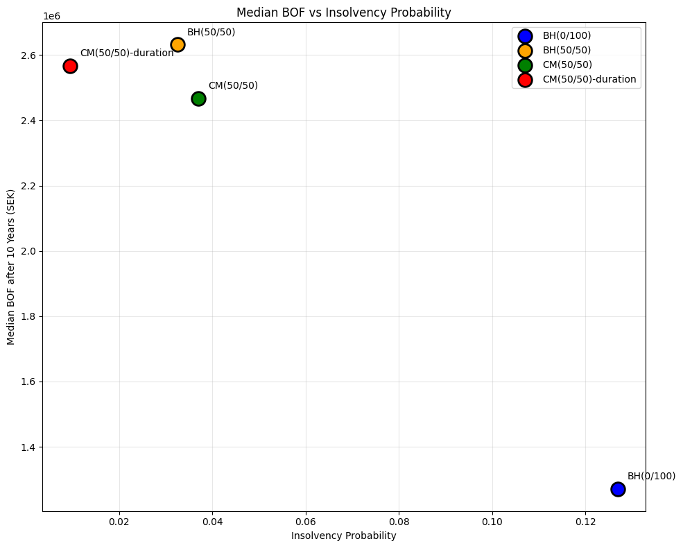

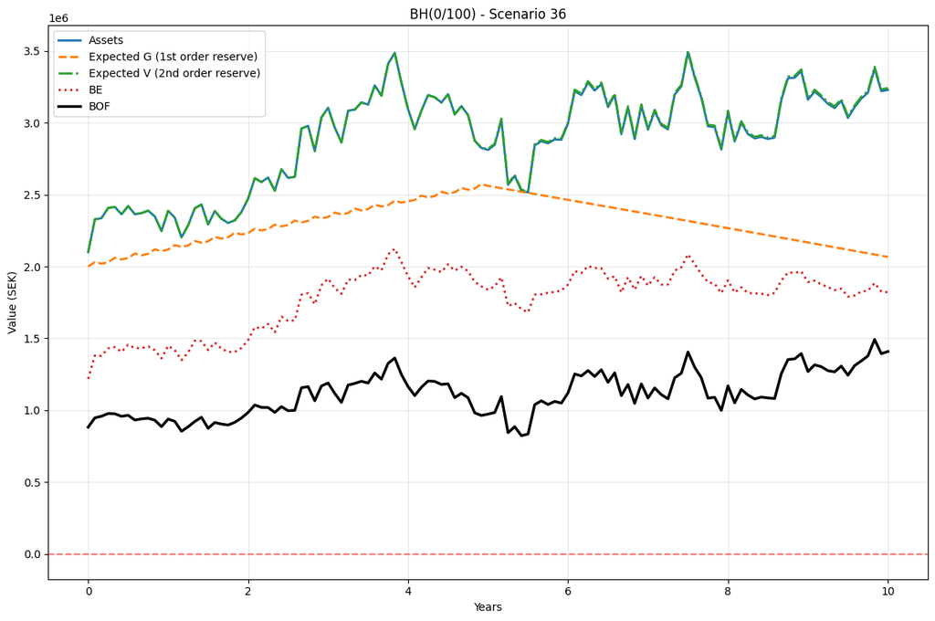

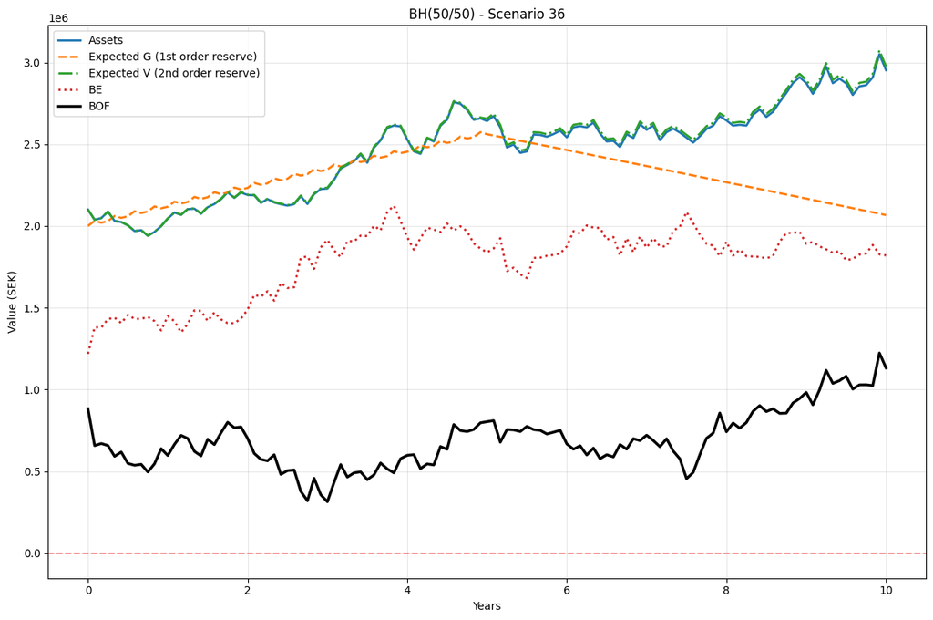

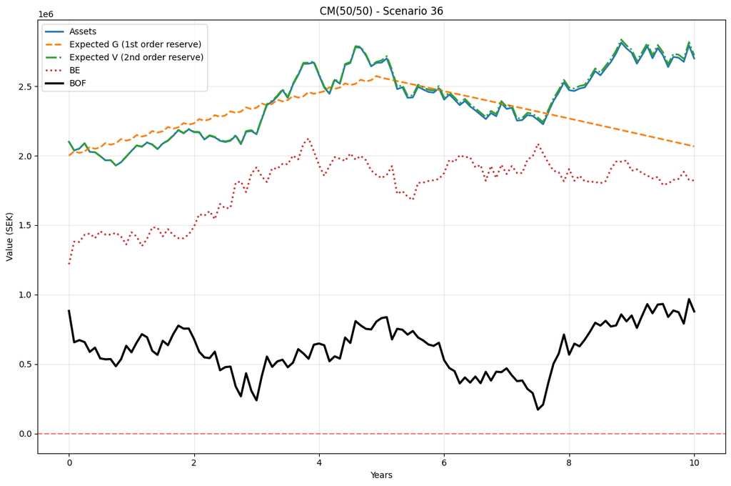

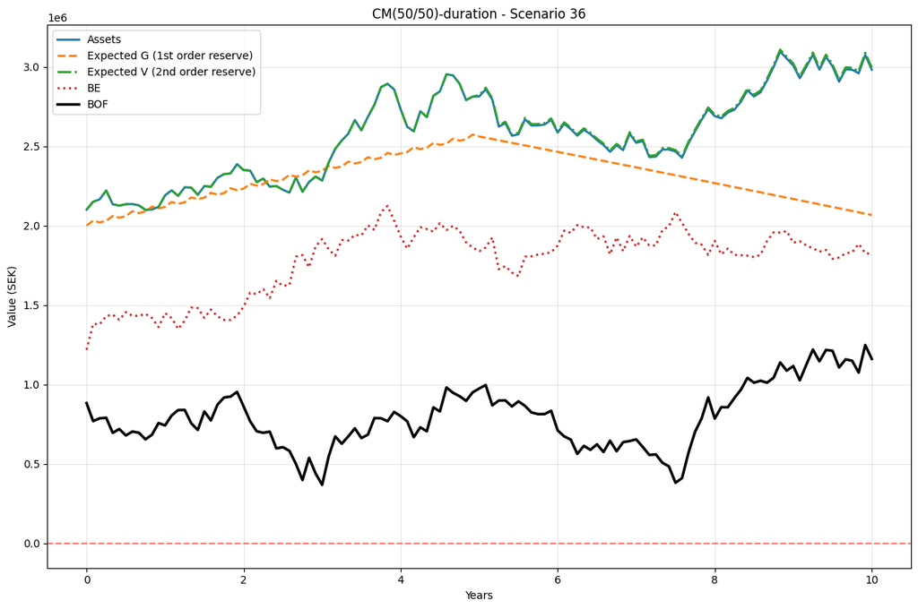

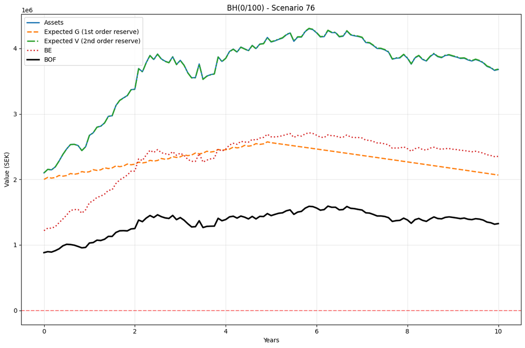

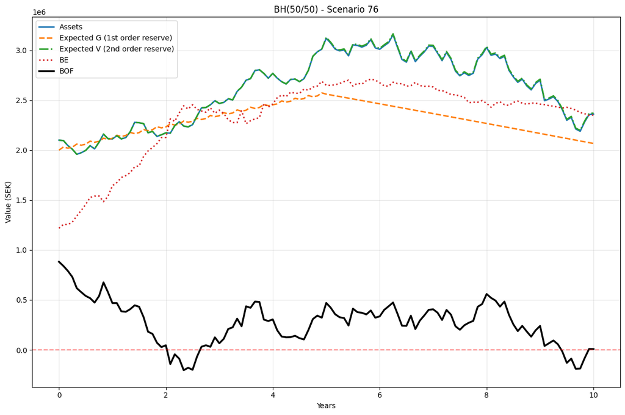

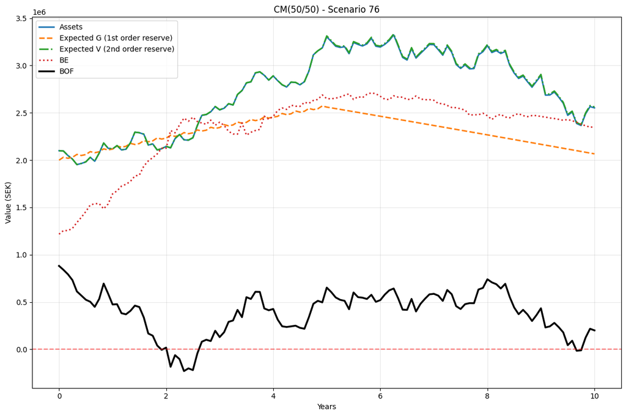

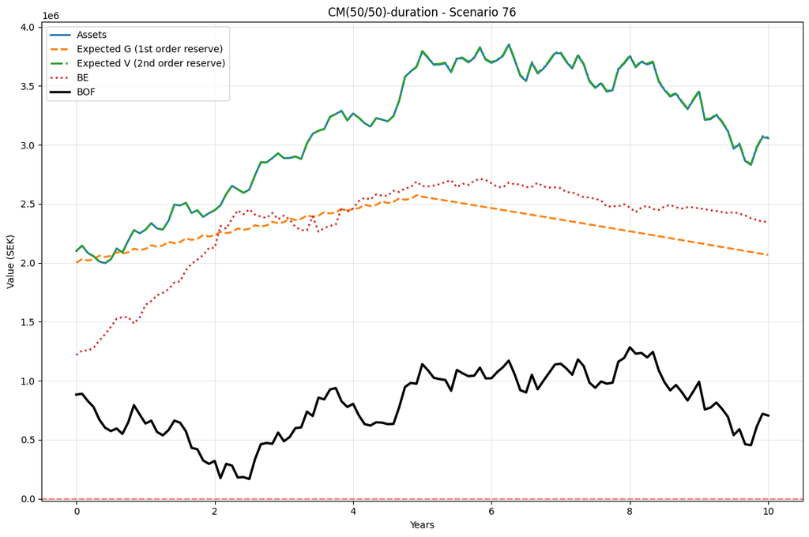

```python
    for i, (strat, med, prob) in enumerate(zip(strategies, medians, insol_probs)):
        plt.scatter(prob, med, s=200, c=colors[i], label=strat, edgecolors='black', linewidth=2)
        plt.annotate(strat, (prob, med), xytext=(10, 10), textcoords='offset points', fontsize=10)

    plt.xlabel('Insolvency Probability')
    plt.ylabel('Median BOF after 10 Years (SEK)')
    plt.title('Median BOF vs Insolvency Probability')
    plt.grid(True, alpha=0.3)
    plt.legend()
    plt.tight_layout()
    plt.savefig('task4_median_insolvency_scatter.png', dpi=150)
    plt.show()

    scenario_indices = [35, 75]
    scenario_numbers = [36, 76]

    for idx, num in zip(scenario_indices, scenario_numbers):
        plot_scenario_evolution(
            A_bh0100[idx], V_bh0100[idx], G_bh0100[idx],
            BE_bh0100[idx], BOF_bh0100[idx],
            num, 'BH(0/100)', f'task4_bh0100_scenario{num}.png', alive_prob_ALM
        )
        plot_scenario_evolution(
            A_bh5050[idx], V_bh5050[idx], G_bh5050[idx],
            BE_bh5050[idx], BOF_bh5050[idx],
            num, 'BH(50/50)', f'task4_bh5050_scenario{num}.png', alive_prob_ALM
        )
        plot_scenario_evolution(
            A_cm5050[idx], V_cm5050[idx], G_cm5050[idx],
            BE_cm5050[idx], BOF_cm5050[idx],
            num, 'CM(50/50)', f'task4_cm5050_scenario{num}.png', alive_prob_ALM
        )
        plot_scenario_evolution(
            A_cmdur[idx], V_cmdur[idx], G_cmdur[idx],
            BE_cmdur[idx], BOF_cmdur[idx],
            num, 'CM(50/50)-duration', f'task4_cmdur_scenario{num}.png', alive_prob_ALM
        )
```

### Exercise 4 Discussion

As CFO, CM(50/50) duration is optimal with lowest insolvency probability (0.95%) and negative SCR (-25,391), indicating BOF growth in the 95th percentile loss scenario. Duration matching hedges interest rate risk by aligning bond portfolio duration with liability duration.

BH(0/100) performs worst with 12.7% insolvency and SCR of 1.05M despite bonds only allocation. The Z15 bond has 15 year duration while liabilities have longer duration, creating mismatch. When rates change, assets and liabilities move differently, causing BOF volatility. BH(50/50) and CM(50/50) show similar performance (~3% insolvency) with stock exposure providing growth potential.

The priority is meeting guaranteed obligations to policyholders, making lowest insolvency probability the deciding factor over median BOF maximization.